# Daily Statistics with R

mynguyen.811.us@gmail.com

1/5/2022

## Unit A: Data

- **Collect** and **describe** data
- **Summarize** and **visualize** data

### Chapter 1. Collecting Data

#### 1.1 The structure of Data

> **Statistics** *is the science of collecting, describing, and analyzing data*.

DATA 1.1: **StudentSurvey**[^1]

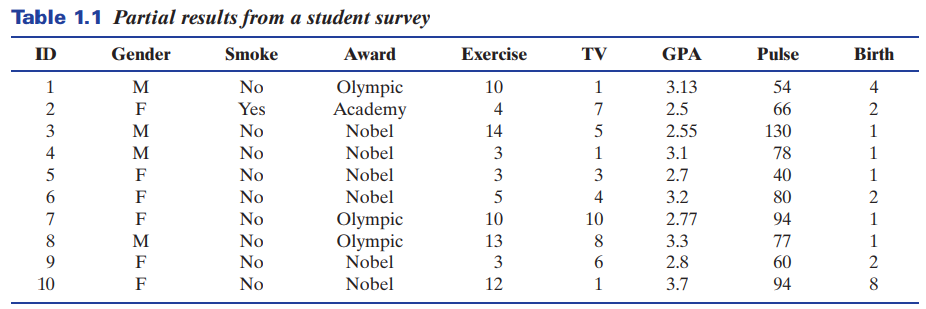

**Case and Variables**  
**Cases** or **units** record the information in a row of a data table. A **variable** is characteristic for each case. Correspond to the column.

**Example 1.1** Explain Student ID 1 variable.

> Student 01 is Male, no smoking, prefer an Olympic gold medal other than Nobel Prize or Academy Award. He exercises 10 hours a week.

**Categorical and Quantitative Variable**  
A **categorical variable** divides the cases into groups, placing each case into exactly one of two or more categories. A **quantitative variable** measures or records a numerical quantity for each case.

**Example 1.2** Classify variables in StudentSurvey table 1.1.

> *Gender* is categorical  
> *Smoke* is categorical  
> *Award* is categorical  
> *Exercise*, *TV*, *GPA*, and *Pulse* are all quantitative  
> *Birth* ambiguous variable.

**Investigating Variables and Relationships between Variables**  
**DATA 1.2 AllCountries**[^2]

```r
install.packages("Lock5Data", repos = "http://cran.us.r-project.org")
library(Lock5Data)
head(AllCountries)
```

```
##          Country Code LandArea Population Density   GDP Rural  CO2 PumpPrice
## 1    Afghanistan  AFG   652.86     37.172    56.9   521  74.5 0.29      0.70
## 2        Albania  ALB    27.40      2.866   104.6  5254  39.7 1.98      1.36
## 3        Algeria  DZA  2381.74     42.228    17.7  4279  27.4 3.74      0.28
## 4 American Samoa  ASM     0.20      0.055   277.3    NA  12.8   NA        NA
## 5        Andorra  AND     0.47      0.077   163.8 42030  11.9 5.83        NA
## 6         Angola  AGO  1246.70     30.810    24.7  3432  34.5 1.29      0.97
##   Military Health ArmedForces Internet  Cell HIV Hunger Diabetes BirthRate
## 1     3.72   2.01         323     11.4  67.4  NA   30.3      9.6      32.5
## 2     4.08   9.51           9     71.8 123.7 0.1    5.5     10.1      11.7
## 3    13.81  10.73         317     47.7 111.0 0.1    4.7      6.7      22.3
## 4       NA     NA          NA       NA    NA  NA     NA       NA        NA
## 5       NA  14.02          NA     98.9 104.4  NA     NA      8.0        NA
## 6     9.40   5.43         117     14.3  44.7 1.9   23.9      3.9      41.3
##   DeathRate ElderlyPop LifeExpectancy FemaleLabor Unemployment Energy
## 1       6.6        2.6           64.0        50.3          1.5     NA
## 2       7.5       13.6           78.5        55.9         13.9    808
## 3       4.8        6.4           76.3        16.4         12.1   1328
## 4        NA         NA             NA          NA           NA     NA
## 5        NA         NA             NA          NA           NA     NA
## 6       8.4        2.5           61.8        76.4          7.3    545
##   Electricity Developed
## 1          NA        NA
## 2        2309         1
## 3        1363         1
## 4          NA        NA
## 5          NA        NA
## 6         312         1
```

**Example 1.3**

1. Determine that 96.5% of Icelanders has access to the Internet, highest rate. What are cases, variable, and is it categorical or quantitative?
2. In the **AllCountries** dataset, what is the cases, variable of the percent of people with access to the Internet for each country. Is it categorical or quantitative?
> 1. The cases are people in Iceland, the relevant variable is whether or not each person has access the internet. This is a categorical variable.
> 2. The cases are countries of the world, variable s the proportion with access to the Internet. It is quantitative.

**Using Data to Answer a Question** **Question** of interest and **collect data** that help to answer that question.

**Example 1.4** *Is there a “Springting Gene”?*

1. The cases are the people included in the study. One variable is whether the individual has the gene variant or not. Since we record simply “yes” or “no,” this is a categorical variable. The second variable keeps track of the group to which the individual belongs. This is also a categorical variable, with three possible categories (sprinter, marathon runner, or non-athlete). We are interested in the relationship between these two categorical variables.
2. The table of data must record answers for each of these variables and may or may not have an identifier column. Table 1.2 shows a possible first two rows for this dataset.

TABLE 1.2 Possible table to investigate whether there is a sprinter’s gene.

[output not shown]

**Explanatory and Response Variables**

> One variable that help understand or predict values of another variable, we call the former the **explanatory variable** and the latter the **response variable**.

**Example 1.5** AllCountries dataset.

1. Do countries larger in area tend to have a more rural population?
2. Is the birth rate higher in developed or undeveloped countries?
> 1. The question indicates that the area might influence the percent of a country that is rural, so we call area the **explanatory variable** and percent rural the **response variable.**
> 2. The explanatory is whether the **country is developed or undeveloped** and the response variable is **birth rate**.

| **SECTION LEARNING GOALS**\ |
| --- |
| 1. Recognize that a dataset consists of **cases** and **variables**\ |
| 2. Identify variables as either **categorical** or **quantitative**\ |
| 3. Determine **explanatory** and **response** variables where appropriate\ |
| 4. Describe how data might be used to address a specific question\ |
| 5. Recognize that understanding statistics allows us to investigate a wide variety of interesting phenomena |

#### 1.2 Sampling from a Population

#### 1.3 Experiments and Observational Studies

### Chapter2. Describing Data

### Chapter 3. Confidence Intervals

### Chapter 4. Hypothesis Tests

## Unit B: Understanding Inference

## Unit B: Essential Synthesis

## Unit C: Inference with Normal and t-Distributions

## Unit D: Inference for Multiple Parameters

## The Big Picture: Essential Synthesis

[^1]: [**http://www.wiley.com/college/lock**](http://www.wiley.com/college/lock)
[^2]: [<http://data.worldbank.org/indicator/IT.NET.USER.P2>](http://data.worldbank.org/indicator/IT.NET.USER.P2)